# Matching in R

Biostatistics Causal Inference Tutorial R

Observational study;  
Causal Inference;  
Matching;  
R;

Hai Nguyen  
July 03, 2021

```r
library(DOS) # Design of Observational Studies
library(tidyverse)
library(kableExtra)
library(optmatch)
```

**Multivariate matching is involved in 3 steps:**  
(i) creating a distance matrix,  
(ii) adding a propensity score caliper to the distance matrix, and  
(iii) finding an optimal match.

Matching in R created largely due to the efforts of Ben Hansen (B. B. Hansen 2007), who created an R function, fullmatch, to do optimal matching from Fortan code created by Demetri Bertsekas D. P. Bertsekas (1981).

## Research questions

**Does financial aid increase college attendance?**

## Goal

**Four matched samples will be constructed:** The construction of one of the four matched samples is presented in step-by-step detail.

## Context

- During [1979-1981 Social Security Student Benefit Program](https://www.rdocumentation.org/packages/DOS/versions/1.0.0/topics/dynarski) provided a substantial tuition benefit for a child of a deceased father, before the cancellation in 1982.
- Analyzing the impact on college attendance and completed schooling of the elimination of the Social Security Student Benefit Program in 1982
- From 1965 to 1982, the Social Security Administration paid for millions of students to go to college. Under this program, the 18- to 22-year-old children of deceased, disabled, or retired Social Security beneficiaries received monthly payments while enrolled full time in college.
- In 1981, Congress voted to eliminate the program. Then was cancelled in 1982
- The program’s demise provides an opportunity to measure the incentive effects of financial aid. Using difference-in-differences methodology, and proxying for benefit eligibility with the death of a parent during an individual’s childhood, found that ? **the elimination of the Social Security student benefit program reduced college attendance probabilities**

### Data

Data `Xb` with 2820 rows and 8 columns:  
- `faminc`: family income in units of $10,000  
- `incmiss`: income missing (1 if family income is missing, 0 o.w.)  
- `black`: 1 if black, 0 o.w.  
- `hispanic`: 1 if hispanic, 0 o.w.  
- `afqtpct`: the Armed Forces Qualifications Test  
- `edm`: mother’s education (1 for less than high school, 2 for high school, 3 for some college, 4 for BA degree or more)  
- `edmissm`: mother’s education missing (1 if missing, 0 o.w.)  
- `female`: gender (1 for female, 0 for male)

> **Imputation:** `faminc` is set to 2 when `incmiss` = 1 indicating that `faminc` is missing, and `edm` is set to 0 when `edmissm`=1 indicating that `edm` is missing

> AFQT was missing for less than 2% of subjects, and these subjects are not used in the matching. With this restriction, there are 131 high school seniors with deceased fathers and 2689 other high school seniors in the 1979-1981 cohort (131+2689 = 2820)

The treatment `zb`, where is 1 if the father is deceased, and 0 o.w.

```r
data("dynarski")
dim(dynarski)
```

```
[1] 2820   10
```

```r
kable(head(dynarski, n=20), caption="First 20 people in the 1979-1981 cohort, the treatment zb and the eight covariates Xb") %>%
  kable_styling(bootstrap_options = "striped", full_width = F)
```

Table 1: First 20 people in the 1979-1981 cohort, the treatment zb and the eight covariates Xb

| id | zb | faminc | incmiss | black | hisp | afqtpct | edmissm | edm | female |
| --- | --- | --- | --- | --- | --- | --- | --- | --- | --- |
| 1 | 0 | 5.3497560 | 0 | 0 | 0 | 71.901660 | 0 | 2 | 0 |
| 2 | 0 | 2.4627060 | 0 | 0 | 0 | 95.158050 | 0 | 2 | 1 |
| 4 | 0 | 9.4876030 | 0 | 0 | 0 | 95.785250 | 0 | 2 | 1 |
| 5 | 0 | 0.4388592 | 0 | 0 | 0 | 90.617160 | 0 | 2 | 1 |
| 6 | 0 | 10.4363600 | 0 | 0 | 0 | 81.761160 | 0 | 2 | 0 |
| 7 | 0 | 6.2694180 | 0 | 0 | 0 | 97.917710 | 0 | 4 | 0 |
| 10 | 1 | 3.2204620 | 0 | 0 | 0 | 61.916710 | 0 | 2 | 1 |
| 11 | 0 | 9.4719470 | 0 | 0 | 0 | 20.446560 | 0 | 2 | 1 |
| 12 | 0 | 2.7167480 | 0 | 0 | 0 | 57.175110 | 0 | 1 | 0 |
| 14 | 0 | 2.0000000 | 1 | 0 | 0 | 8.278976 | 0 | 1 | 1 |
| 15 | 0 | 7.1157020 | 0 | 0 | 0 | 50.928250 | 0 | 2 | 1 |
| 16 | 0 | 7.7669970 | 0 | 0 | 0 | 71.149020 | 0 | 2 | 1 |
| 17 | 0 | 12.5388400 | 0 | 0 | 0 | 74.912190 | 0 | 2 | 0 |
| 18 | 0 | 2.0000000 | 1 | 0 | 0 | 98.394380 | 0 | 2 | 1 |
| 21 | 0 | 9.4041260 | 0 | 0 | 0 | 98.720520 | 0 | 4 | 1 |
| 23 | 0 | 2.0000000 | 1 | 0 | 0 | 99.724040 | 0 | 4 | 0 |
| 24 | 0 | 2.0000000 | 1 | 0 | 0 | 73.281490 | 0 | 3 | 1 |
| 29 | 0 | 2.0000000 | 1 | 1 | 0 | 1.781234 | 0 | 1 | 0 |
| 31 | 0 | 2.0000000 | 1 | 0 | 0 | 42.900150 | 0 | 2 | 1 |
| 34 | 1 | 2.6090910 | 0 | 0 | 0 | 99.623680 | 0 | 2 | 0 |

```r
#write.csv(dynarski, file="dynarski.csv")
```

```r
zb<-dynarski$zb
zbf<-factor(zb,levels=c(1,0),labels=c("Father deceased","Father not deceased"))
table(zbf)
```

```
zbf
    Father deceased Father not deceased
                131                2689
```

```r
Xb<-dynarski[,3:10]
```

$\Rightarrow$ The 131 seniors with deceased fathers will each be matched to 10 controls whose fathers were not deceased.

### Covariates with Missing Values

```r
with(dynarski, table(incmiss))
```

```
incmiss
   0    1
2282  538
```

```r
incmiss.per<-round(table(dynarski$incmiss)[2]/dim(dynarski)[1]*100,1)
paste0("Percentage of income missing: ", incmiss.per)
```

```
[1] "Percentage of income missing: 19.1"
```

```r
with(dynarski, table(edmissm))
```

```
edmissm
   0    1
2704  116
```

```r
edmissm.per<-round(table(dynarski$edmissm)[2]/dim(dynarski)[1]*100,1)
paste0("Percentage of mother's education missing: ", edmissm.per)
```

```
[1] "Percentage of mother's education missing: 4.1"
```

Discussion of the missing covariate values will be later on another post.

## Propensity Score

The propensity score is estimated using a logit model.

```r
# Estimate the propensity score
p <- glm(zb ~ Xb$faminc + Xb$incmiss + Xb$black + Xb$hisp + Xb$afqtpct + Xb$edmissm + Xb$edm + Xb$female, family = binomial)$fitted.values
```

$\Rightarrow$ The vector `p` contains the 2820 estimated propensity scores, $\hat{e}(\mathbf{x}_l)$, $l$ = 1, 2, …, 2820.

> It is reasonable to be able to improve the model: perhaps including interaction terms or transformations or polynomials or whatnot.

Estimated propensity scores for 131 seniors with deceased fathers and 2689 other seniors in the 1979-1981 cohort, before the Social Security Student Benefit Program was eliminated.

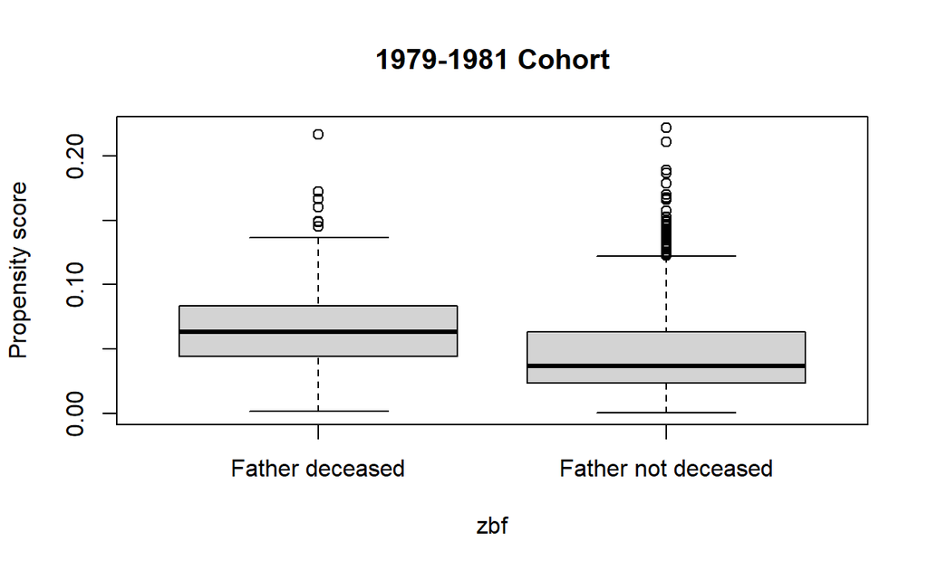

```r
boxplot(p~zbf, ylab="Propensity score", main="1979-1981 Cohort")
```

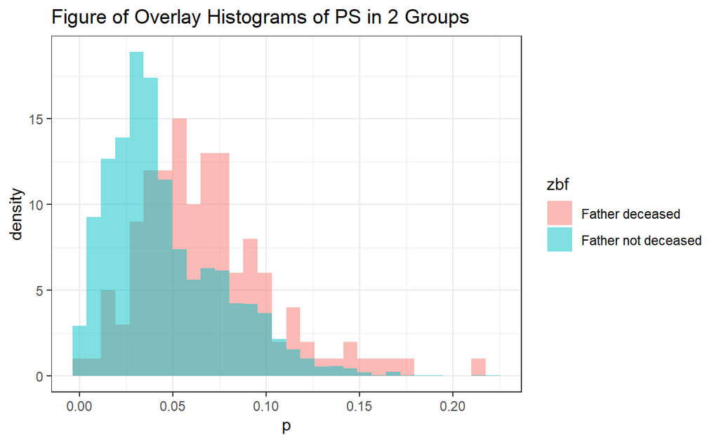

```r
dynarski$p <- p
ggplot(dynarski, aes(p, fill = zbf)) +
  geom_histogram(alpha = 0.5, aes(y = ..density..), position = 'identity') +
  ggtitle("Figure of Overlay Histograms of PS in 2 Groups") +
  theme_bw()
```

$\Longrightarrow$ the median $\hat{e}(\mathbf{x})$ in the treated group (0.064) is about equal to the upper quartile among potential controls (0.063). Nonetheless, the distributions in Figure of Overlay Histogram of PS in 2 Groups overlap substantially, so matching appears to be possible.

## Distance Matrix

Constructing in 2 steps:  
- Step 1: computing the rankbased Mahalanobis distance $\rightarrow$ 131x2689 distance matrix

```r
#Robust Mahalanobis distance matrix, treated x control
dmat<-smahal(zb,Xb)
dim(dmat)
```

```
[1]  131 2689
```

```r
kable(round(dmat[1:5,1:5],2), caption="First five rows and columns of the 131×2689 distance matrix using the rank-based Mahalanobis distance") %>%
  kable_styling(bootstrap_options = "striped", full_width = F)
```

Table 2: First five rows and columns of the 131×2689 distance matrix using the rank-based Mahalanobis distance

|  | 1 | 2 | 3 | 4 | 5 |
| --- | --- | --- | --- | --- | --- |
| 7 | 3.86 | 2.61 | 5.06 | 6.86 | 6.72 |
| 20 | 3.47 | 3.03 | 7.58 | 6.23 | 5.82 |
| 108 | 9.60 | 19.47 | 20.02 | 24.62 | 13.03 |
| 126 | 6.81 | 8.05 | 12.93 | 10.74 | 9.88 |
| 145 | 8.70 | 15.09 | 17.74 | 18.86 | 12.37 |

- Step 2: adding the caliper on the propensity score. The caliper was at $0.2 \times sd(\hat{e}(\mathbf{x}))$.

```r
#Add a caliper on the propensity score using a penalty function
dmat<-addcaliper(dmat,zb,p,caliper=.2)
dim(dmat)
```

```
[1]  131 2689
```

```r
kable(round(dmat[1:5,1:5],2), caption="First five rows and columns of the 131×2689 distance matrix after adding the propensity score calipers") %>%
  kable_styling(bootstrap_options = "striped", full_width = F)
```

Table 3: First five rows and columns of the 131×2689 distance matrix after adding the propensity score calipers

|  | 1 | 2 | 3 | 4 | 5 |
| --- | --- | --- | --- | --- | --- |
| 7 | 18.60 | 20.64 | 42.04 | 79.91 | 46.10 |
| 20 | 46.32 | 3.03 | 72.66 | 51.18 | 73.30 |
| 108 | 82.94 | 47.40 | 115.60 | 39.07 | 111.01 |
| 126 | 57.81 | 13.64 | 86.16 | 47.54 | 85.51 |
| 145 | 8.70 | 54.51 | 33.32 | 113.31 | 30.34 |

$\Rightarrow$ Among these 25 entries, only 2 respected the caliper and did not incur a penalty (3.03 and 8.70).

## Constructing the Match (B. B. Hansen 2007)

Matching ten controls to each senior with a deceased father: The `fullmatch` function needs to know the distance matrix, here `dmat`, matching 10-to-1 means 10x131 will be used, omitting 2689−10x131 = 1379, which is the omit fraction be: 51%.

```r
m<-fullmatch(dmat, data=dynarski, min.controls=10, max.controls=10, omit.fraction=1379/2689)
```

There is an entry in m for each of the 2820 seniors

```r
length(m)
```

```
[1] 2820
```

The first ten entries in m are

```r
m[1:10]
```

```
    1     2     3     4     5     6     7     8     9    10
1.129 1.100  <NA>  1.54  <NA> 1.121 1.114  <NA> 1.111  1.87
```

The function matched(·) indicates who is matched. The first ten entries of matched(m) are

```r
matched(m)[1:10]
```

```
    1     2     3     4     5     6     7     8     9    10
 TRUE  TRUE FALSE  TRUE FALSE  TRUE  TRUE FALSE  TRUE  TRUE
```

the first two seniors were matched but the third was not, and so on.

There are 1441 matched seniors, where 1441 = 131×11, because the 131 seniors with deceased fathers were each matched to ten controls, making 131 matched sets each of size 11.

```r
sum(matched(m))
```

```
[1] 1441
```

```r
sum(matched(m))/11
```

```
[1] 131
```

The first 3 matched sets are in Table below. The first match consists of 11 female high school seniors, neither black nor hispanic, whose mothers had a high school education, with family incomes between $30,000 and $40,000, mostly with test scores between 59% and 77%. In the second matched set, incomes were lower but test scores were higher. And so on.

```r
# Housekeeping
im<-as.integer(m) # matched set from 1 to 131
dynarski<-cbind(dynarski,im)
dm<-dynarski[matched(m),] # only select matched cases, note that matched(m): T\F
dm<-dm[order(dm$im,1-dm$zb),] # sort data according to matched set then zb decreasing

# Table of matched set example
#which(dm$id==10) # [1] 188
#which(dm$id==396) # [1] 23
#which(dm$id==3051) # [1] 1068

kable(rbind(dm[188:198,-c(11,12)], dm[23:33,-c(11,12)],dm[1068:1078,-c(11,12)]), caption="The 3 of 131 matched sets, each set containing one treated subject and 10 matched controls") %>%
  kable_styling(bootstrap_options = "striped", full_width = F)
```

(#tab:matched set ex)The 3 of 131 matched sets, each set containing one treated subject and 10 matched controls

|  | id | zb | faminc | incmiss | black | hisp | afqtpct | edmissm | edm | female |
| --- | --- | --- | --- | --- | --- | --- | --- | --- | --- | --- |
| 7 | 10 | 1 | 3.220462 | 0 | 0 | 0 | 61.91671 | 0 | 2 | 1 |
| 239 | 350 | 0 | 3.557851 | 0 | 0 | 0 | 59.58355 | 0 | 2 | 1 |
| 252 | 365 | 0 | 3.599340 | 0 | 0 | 0 | 61.23934 | 0 | 2 | 1 |
| 322 | 465 | 0 | 3.557851 | 0 | 0 | 0 | 56.37230 | 0 | 2 | 1 |
| 361 | 518 | 0 | 3.788779 | 0 | 0 | 0 | 67.00953 | 0 | 2 | 1 |
| 383 | 550 | 0 | 3.788779 | 0 | 0 | 0 | 63.49724 | 0 | 2 | 1 |
| 928 | 1294 | 0 | 3.557851 | 0 | 0 | 0 | 67.31059 | 0 | 2 | 1 |
| 1481 | 2072 | 0 | 3.788779 | 0 | 0 | 0 | 64.97742 | 0 | 2 | 1 |
| 1489 | 2082 | 0 | 3.788779 | 0 | 0 | 0 | 63.62268 | 0 | 2 | 1 |
| 1560 | 2183 | 0 | 3.970631 | 0 | 0 | 0 | 76.51781 | 0 | 2 | 1 |
| 2810 | 3965 | 0 | 3.761650 | 0 | 0 | 0 | 72.57903 | 0 | 2 | 1 |
| 268 | 396 | 1 | 2.371901 | 0 | 0 | 0 | 88.50979 | 0 | 2 | 1 |
| 2 | 2 | 0 | 2.462706 | 0 | 0 | 0 | 95.15805 | 0 | 2 | 1 |
| 101 | 147 | 0 | 2.273267 | 0 | 0 | 0 | 77.09483 | 0 | 2 | 1 |
| 375 | 537 | 0 | 2.595314 | 0 | 0 | 0 | 95.96086 | 0 | 2 | 1 |
| 665 | 933 | 0 | 2.846281 | 0 | 0 | 0 | 96.11139 | 0 | 2 | 1 |
| 698 | 974 | 0 | 1.897521 | 0 | 0 | 0 | 99.59859 | 0 | 3 | 1 |
| 707 | 987 | 0 | 2.134711 | 0 | 0 | 0 | 81.18414 | 0 | 2 | 1 |
| 1394 | 1947 | 0 | 2.050298 | 0 | 0 | 0 | 91.44506 | 0 | 3 | 1 |
| 1518 | 2124 | 0 | 2.298786 | 0 | 0 | 0 | 72.40341 | 0 | 2 | 1 |
| 1877 | 2618 | 0 | 2.211560 | 0 | 0 | 0 | 68.91621 | 0 | 2 | 1 |
| 2816 | 3975 | 0 | 2.371901 | 0 | 0 | 0 | 90.74260 | 0 | 2 | 1 |
| 2182 | 3051 | 1 | 3.409901 | 0 | 0 | 1 | 62.87004 | 0 | 1 | 0 |
| 427 | 606 | 0 | 4.179612 | 0 | 0 | 1 | 81.73608 | 0 | 1 | 0 |
| 472 | 664 | 0 | 4.388592 | 0 | 0 | 1 | 91.57050 | 0 | 1 | 0 |
| 628 | 884 | 0 | 2.846281 | 0 | 0 | 1 | 48.77070 | 0 | 1 | 0 |
| 713 | 995 | 0 | 3.134709 | 0 | 0 | 1 | 55.11791 | 0 | 1 | 0 |
| 724 | 1008 | 0 | 3.320661 | 0 | 0 | 1 | 51.60562 | 0 | 1 | 0 |
| 1006 | 1399 | 0 | 3.439256 | 0 | 0 | 1 | 90.01505 | 0 | 2 | 0 |
| 2087 | 2908 | 0 | 3.795041 | 0 | 0 | 1 | 80.28098 | 0 | 1 | 0 |
| 2328 | 3262 | 0 | 3.788779 | 0 | 0 | 1 | 57.27546 | 0 | 1 | 0 |
| 2424 | 3400 | 0 | 2.925728 | 0 | 0 | 1 | 80.88309 | 0 | 2 | 0 |
| 2576 | 3624 | 0 | 3.320661 | 0 | 0 | 1 | 74.08430 | 0 | 1 | 1 |

## Checking Covariate Balance

Note that: for covariate $k$,  
- $\bar{x}_{tk}$ is the mean in the first group in the comparison,  
- $\bar{x}_{ck}$ is the mean in the second group in the comparison, and  
- $\bar{x}_{mck}$ is the mean in the matched comparison group formed from the second group  
- $sd_{bk}$ is the standardized difference in means before matching and  
- $sd_{mk}$ is the standardized difference in means after matching; they have the same denominator but different numerators

```r
#fd <- dynarski[dynarski$zb==1,-c(1,2,12)]
#round(apply(fd, 2, FUN=mean),2)

d.tk<-dynarski %>%
  filter(zb==1) %>%
  mutate(faminc=ifelse(incmiss==1,NA, faminc),
         edm=ifelse(edmissm==1, NA, edm)) %>%
  select(-id,-zb,-im)
x.tk<-d.tk %>% summarise_all(mean, na.rm=TRUE)
s.tk<-d.tk %>% summarise_all(sd, na.rm=TRUE)

d.ck<-dynarski %>%
  filter(zb==0) %>%
  mutate(faminc=ifelse(incmiss==1,NA, faminc),
         edm=ifelse(edmissm==1, NA, edm)) %>%
  select(-id,-zb,-im)
x.ck<-d.ck %>% summarise_all(mean, na.rm=TRUE)
s.ck<-d.ck %>% summarise_all(sd, na.rm=TRUE)

sd.bk<-abs(x.tk-x.ck)/sqrt((s.tk^2+s.ck^2)/2)

d.cmk<-dm %>%
  filter(zb==0) %>%
  mutate(faminc=ifelse(incmiss==1,NA, faminc),
         edm=ifelse(edmissm==1, NA, edm)) %>%
  select(-id,-zb,-im)
x.cmk<-d.cmk %>% summarise_all(mean, na.rm=TRUE)
sd.cmk<-abs(x.tk-x.cmk)/sqrt((s.tk^2+s.ck^2)/2)

set<-round(rbind(x.tk,x.cmk,x.ck,sd.bk,sd.cmk),2)
row.names(set) <- c("x.tk","x.cmk","x.ck","sd.bk","sd.cmk")

kable(set, caption="Balance on covariates before and after matching") %>%
  kable_styling(bootstrap_options = "striped", full_width = F)
```

Table 4: Balance on covariates before and after matching

|  | faminc | incmiss | black | hisp | afqtpct | edmissm | edm | female | p |
| --- | --- | --- | --- | --- | --- | --- | --- | --- | --- |
| x.tk | 2.78 | 0.15 | 0.35 | 0.15 | 49.58 | 0.08 | 1.62 | 0.49 | 0.07 |
| x.cmk | 2.77 | 0.15 | 0.34 | 0.15 | 49.10 | 0.04 | 1.61 | 0.50 | 0.06 |
| x.ck | 4.58 | 0.19 | 0.29 | 0.15 | 52.39 | 0.04 | 1.91 | 0.50 | 0.05 |
| sd.bk | 0.71 | 0.11 | 0.13 | 0.02 | 0.10 | 0.19 | 0.33 | 0.03 | 0.67 |
| sd.cmk | 0.00 | 0.00 | 0.02 | 0.03 | 0.02 | 0.19 | 0.02 | 0.02 | 0.09 |

## Outcomes

The outcomes were not provided in the Dynarski’s dataset. But I guessed we can report the proportions and MH-odds ratio between 2 groups after matching.

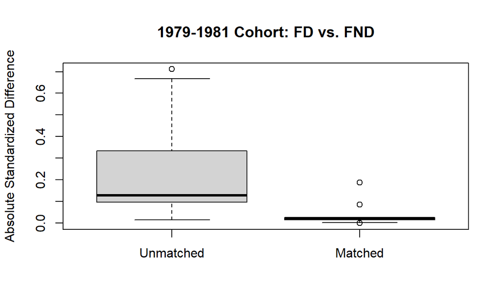

```r
m<-c(0,1)
d.sd<-rbind(sd.bk,sd.cmk)
d.sd<-cbind(d.sd,m)
d.sd.long<-d.sd %>%
  pivot_longer(-m,names_to="absstdzdiff", values_to="sd")
d.sd.long$m<-factor(d.sd.long$m,levels=c(0,1),labels=c("Unmatched","Matched"))
boxplot(sd~m, data=d.sd.long, xlab="", ylab="Absolute Standardized Difference", main="1979-1981 Cohort: FD vs. FND")
```

## Further reading

- Dynarski (1999)’s fine study
- B. B. Hansen (2007)’s `fullmatch` function
- Ben B. Hansen and Klopfer (2006), Paul R. Rosenbaum (1989), P. R. Rosenbaum (1991) showed how `fullmatch` is doing
- Ming and Rosenbaum (2001) showed `proc assign` in SAS

Bertsekas. 1991. *Linear Network Optimization*. Book. Cambridge, MA: MIT Press. http://web.mit.edu/dimitrib/www/net.html.

Bertsekas, Dimitri P. 1981. “A New Algorithm for the Assignment Problem.” Journal Article. *Mathematical Programming* 21 (1): 152–71. https://doi.org/10.1007/BF01584237.

Dynarski, Susan M. 1999. “Does Aid Matter? Measuring the Effect of Student Aid on College Attendance and Completion.” Journal Article, 1 online resource. http://HZ9PJ6FE4T.search.serialssolutions.com/?V=1.0&L=HZ9PJ6FE4T&S=JCs&C=TC_008322359&T=marc&tab=BOOKS Available only to UIC users.

Hansen, B. B. 2007. “Optmatch: Flexible, Optimal Matching for Observational Studies.” Journal Article. *R News* 7: 18–24.

Hansen, Ben B., and Stephanie Olsen Klopfer. 2006. “Optimal Full Matching and Related Designs via Network Flows.” Journal Article. *Journal of Computational and Graphical Statistics* 15 (3): 609–27. www.jstor.org/stable/27594200.

Ming, Kewei, and Paul R. Rosenbaum. 2001. “A Note on Optimal Matching with Variable Controls Using the Assignment Algorithm.” Journal Article. *Journal of Computational and Graphical Statistics* 10 (3): 455–63. www.jstor.org/stable/1391099.

Rosenbaum, P. R. 1991. “A Characterization of Optimal Designs for Observational Studies.” Journal Article. *Journal of the Royal Statistical Society. Series B (Methodological)* 53 (3): 597–610. www.jstor.org/stable/2345589.

Rosenbaum, Paul R. 1989. “Optimal Matching for Observational Studies.” Journal Article. *Journal of the American Statistical Association* 84 (408): 1024–32. https://doi.org/10.2307/2290079.